# DDP_Course_Project_Presentation

Mike Crabtree

February 6, 2017

# Introduction

The Shiny app I developed is my first Shiny app, and involves data from High School students and aspects of their lives including how often they consume alcohol.

The purpose of this app is to perform some basic data exploration on the dataset using an interactive Shiny app.

The live demo on shinyapps.io can be found [here](https://mcrabtree.shinyapps.io/Developing_Data_Products_Project/)

# Data

The data can be found on Kaggle [here](https://www.kaggle.com/uciml/student-alcohol-consumption)

The data were obtained in a survey of students math and portuguese language courses in secondary school. It contains a lot of interesting social, gender and study information about students. You can use it for some EDA or try to predict students final grade.

The list of features available in the dataset is listed on the above linked page on Kaggle.

# Structure of the Data

Below is the details about the structure of the data.

```
## 'data.frame':    649 obs. of  33 variables:
##  $ school    : chr  "GP" "GP" "GP" "GP" ...
##  $ sex       : chr  "F" "F" "F" "F" ...
##  $ age       : int  18 17 15 15 16 16 16 17 15 15 ...
##  $ address   : chr  "U" "U" "U" "U" ...
##  $ famsize   : chr  "GT3" "GT3" "LE3" "GT3" ...
##  $ Pstatus   : chr  "A" "T" "T" "T" ...
##  $ Medu      : int  4 1 1 4 3 4 2 4 3 3 ...
##  $ Fedu      : int  4 1 1 2 3 3 2 4 2 4 ...
##  $ Mjob      : chr  "at_home" "at_home" "at_home" "health" ...
##  $ Fjob      : chr  "teacher" "other" "other" "services" ...
##  $ reason    : chr  "course" "course" "other" "home" ...
##  $ guardian  : chr  "mother" "father" "mother" "mother" ...
##  $ traveltime: int  2 1 1 1 1 1 1 2 1 1 ...
##  $ studytime : int  2 2 2 3 2 2 2 2 2 2 ...
```

[output cut: 19 more lines]

# The App

Example Output:

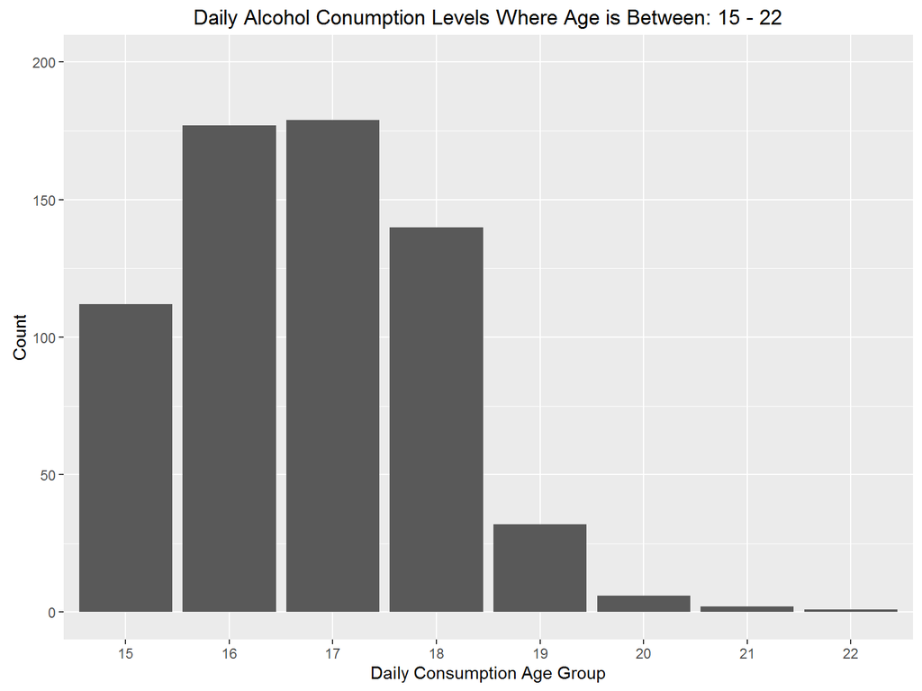

The source code for the app can be found [here](https://github.com/Mdcrab02/Developing_Data_Products_Project)